# Isle of Skye Vegetation Survey - Birks (1973)

Exploratory Data Analysis

Bhagyesh and Pawan

# 1 · Survey Overview

**Data provenance & quality.** 26,799 species-by-plot observations across 520 survey plots (releves) and 54 vegetation tables, digitised from H.J.B. Birks (1973), *The Present Flora and Vegetation of the Isle of Skye*. **100% of plots are geolocated and every coordinate has been verified to fall on the Skye landmass** (British National Grid references converted to WGS84 and point-in-polygon checked against the OpenStreetMap Skye boundary). No rows remain flagged for review (`needs_review = 0`). Report generated 02 July 2026.

### Key findings

- **Scale.** 26,799 observations, 897 distinct taxa, 520 plots across 23 vegetation classes and 67 associations.
- **Most sampled community.** *SCHEUCHZERIO-CARICETEA FUSCAE* is the best-represented class (76 releves).
- **Most frequent species.** *Potentilla erecta* is present in the most plots (137 releves).
- **Geographic span.** Plots range 57.03–57.70°N and -6.78–-5.71°E, following Skye’s SW–NE axis.
- **Structure.** Releves resolve into a 10-cluster Ward/Jaccard solution; statistical support (PERMANOVA) and indicator species are in Section 9.

Table 1. Dataset at a glance.

| Metric | Value |
| --- | --- |
| Observation rows | 26,799 |
| Survey plots (releves) | 520 |
| Vegetation classes | 23 |
| Alliances | 37 |
| Associations | 67 |
| Species (standardised) | 897 |
| Releves with coordinates | 520 |

Each releve is assigned a geographic index (`geo_id`) from 1 (south-westernmost) to 520 (north-easternmost), derived by sorting on latitude then longitude to follow Skye’s SW-NE orientation.

# 2 · Survey Design Map

## Interactive Map

Click any marker to see full releve details. Colour = vegetation class.

[interactive chart not shown]

# 3 · Vegetation Classes & Associations

## Releves per Vegetation Class

[interactive chart not shown]

## Top 10 Associations by Releve Count

[interactive chart not shown]

### Full Association Table

|  | Class | Association | Releves |
| --- | --- | --- | --- |
| 1 | ASTERETEA TRIPOLIUM | Juncus gerardii-Carex extensa | 17 |
| 2 | CARICETEA CURVULAE | Cariceto-Rhacomitretum lanuginosi | 17 |
| 3 | OXYCOCCO-SPHAGNETEA | Trichophoreto-Eriophoretum | 15 |
| 4 | ASPLENIETEA RUPESTRIS | Asplenium trichomanes-Fissidens cristatus | 14 |
| 5 | BETULO-ADENOSTYLETEA | Betula pubescens-Cirsium heterophyllum / Sedum rosea-Alchemilla glabra | 14 |
| 6 | CARICETEA CURVULAE | Rhacomitreto-Callunettum | 14 |
| 7 | NARDO-CALLUNETEA | Calluna vulgaris-Sieglingia decumbens | 14 |
| 8 | OXYCOCCO-SPHAGNETEA | Trichophoreto-Callunetum | 14 |
| 9 | QUERCETEA ROBORI-PETRAEAE | Oxalis acetosella-Rhytidiadelphus loreus | 14 |
| 10 | QUERCETEA ROBORI-PETRAEAE | Betula pubescens-Vaccinium myrtillus / Corylus avellana-Oxalis acetosella | 13 |

[output cut: 57 more lines]

# 4 · Species Frequency

## Top 10 Most-Frequent Species

[interactive chart not shown]

## 10 Rarest Species (Globally)

[interactive chart not shown]

[output not shown]

# 5 · Top-10 & Rarest-10 Species per Association

Each panel shows the **top 10** (or rarest 10) species within that association, ranked by % of the association’s releves. Hover for exact values. Use the tabs to switch between the most-frequent and rarest species per community.

## Top-10 Species per Association

[figure not shown]

### Top-10 Table (searchable)

|  | Class | Association | Species | Releves (n) | Assoc. releves | % present |
| --- | --- | --- | --- | --- | --- | --- |
| 1 | ALNETEA GLUTINOSAE | Alnus glutinosa woods | Acrocladium cuspidatum | 1 | 1 | 100 |
| 2 | ALNETEA GLUTINOSAE | Alnus glutinosa woods | Alnus glutinosa | 1 | 1 | 100 |
| 3 | ALNETEA GLUTINOSAE | Alnus glutinosa woods | Alopecurus geniculatus | 1 | 1 | 100 |
| 4 | ALNETEA GLUTINOSAE | Alnus glutinosa woods | Anthoxanthum odoratum | 1 | 1 | 100 |
| 5 | ALNETEA GLUTINOSAE | Alnus glutinosa woods | Athyrium filix-femina | 1 | 1 | 100 |
| 6 | ALNETEA GLUTINOSAE | Alnus glutinosa woods | Brachythecium rutabulum | 1 | 1 | 100 |
| 7 | ALNETEA GLUTINOSAE | Alnus glutinosa woods | Caltha palustris | 1 | 1 | 100 |
| 8 | ALNETEA GLUTINOSAE | Alnus glutinosa woods | Cardamine flexuosa | 1 | 1 | 100 |
| 9 | ALNETEA GLUTINOSAE | Alnus glutinosa woods | Cirsium palustre | 1 | 1 | 100 |
| 10 | ALNETEA GLUTINOSAE | Alnus glutinosa woods | Dactylorhiza fuchsii | 1 | 1 | 100 |

[output cut: 656 more lines]

## 10 Rarest Species per Association

[figure not shown]

### Rarest-10 Table (searchable)

|  | Class | Association | Species | Releves (n) | Assoc. releves | % present |
| --- | --- | --- | --- | --- | --- | --- |
| 1 | ALNETEA GLUTINOSAE | Alnus glutinosa woods | Acrocladium cuspidatum | 1 | 1 | 100 |
| 2 | ALNETEA GLUTINOSAE | Alnus glutinosa woods | Alnus glutinosa | 1 | 1 | 100 |
| 3 | ALNETEA GLUTINOSAE | Alnus glutinosa woods | Alopecurus geniculatus | 1 | 1 | 100 |
| 4 | ALNETEA GLUTINOSAE | Alnus glutinosa woods | Anthoxanthum odoratum | 1 | 1 | 100 |
| 5 | ALNETEA GLUTINOSAE | Alnus glutinosa woods | Athyrium filix-femina | 1 | 1 | 100 |
| 6 | ALNETEA GLUTINOSAE | Alnus glutinosa woods | Brachythecium rutabulum | 1 | 1 | 100 |
| 7 | ALNETEA GLUTINOSAE | Alnus glutinosa woods | Caltha palustris | 1 | 1 | 100 |
| 8 | ALNETEA GLUTINOSAE | Alnus glutinosa woods | Cardamine flexuosa | 1 | 1 | 100 |
| 9 | ALNETEA GLUTINOSAE | Alnus glutinosa woods | Cirsium palustre | 1 | 1 | 100 |
| 10 | ALNETEA GLUTINOSAE | Alnus glutinosa woods | Dactylorhiza fuchsii | 1 | 1 | 100 |

[output cut: 656 more lines]

# 6 · Domin Cover Scores

The **Domin scale** runs 1 → 10: from sparse presence (<4% cover) to near-complete dominance (96–100%). Higher scores mean the species blankets the plot.

## Overall Domin Distribution

[interactive chart not shown]

## Domin Distribution - Top 10 Associations

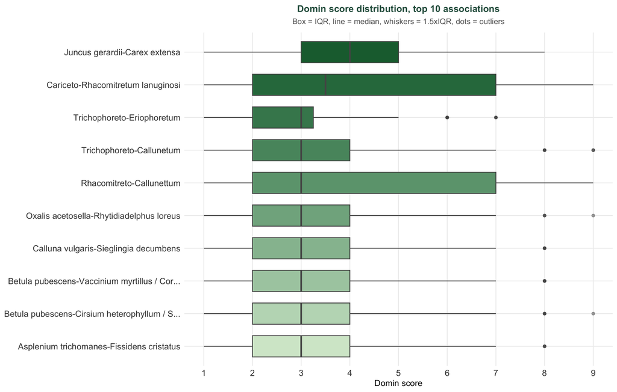

## Top 10 Species by Mean Domin Score

[interactive chart not shown]

# 7 · Community Matrix & Clustering

Binary (presence/absence) releve x species matrix, species present in 3 or more releves only. Clustered with Ward’s D2 on Jaccard dissimilarities.

Table 6. Community matrix dimensions.

[output not shown]

## Hierarchical Clustering (Ward / Jaccard)

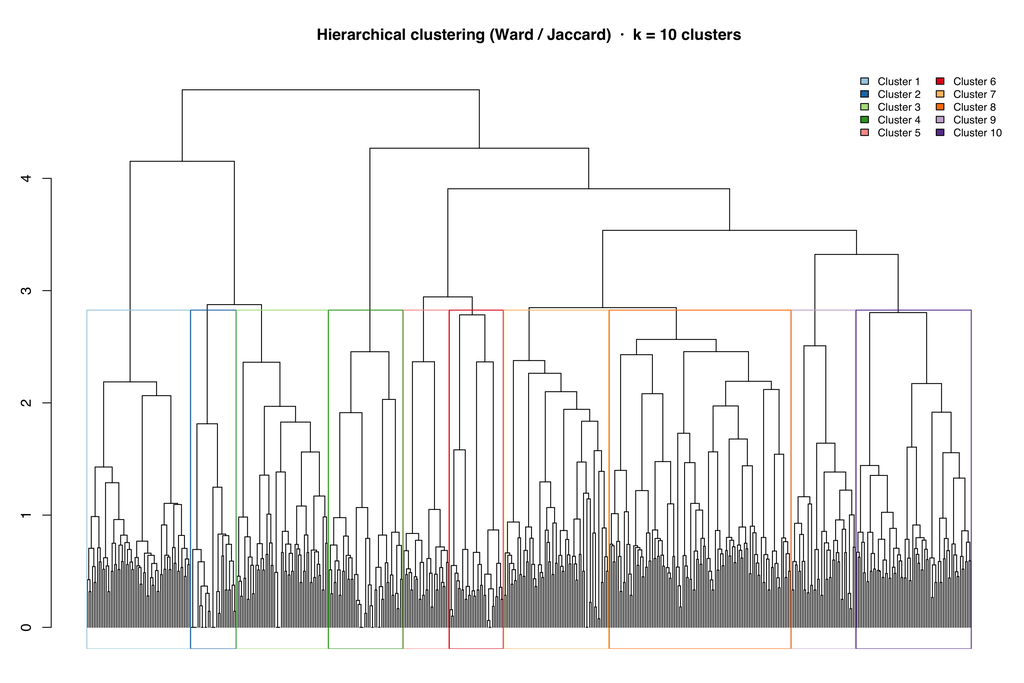

## Cluster × Association Membership

|  | Class | Association | C2 | C9 | C6 | C8 | C7 | C5 | C1 | C3 | C4 | C10 |
| --- | --- | --- | --- | --- | --- | --- | --- | --- | --- | --- | --- | --- |
| 1 | ALNETEA GLUTINOSAE | Alnus glutinosa woods | 1 | 0 | 0 | 0 | 0 | 0 | 0 | 0 | 0 | 0 |
| 2 | ALNETEA GLUTINOSAE | Epiphytic bryophytes and lichens in Alnus glutinosa woods | 2 | 0 | 0 | 0 | 0 | 0 | 0 | 0 | 0 | 0 |
| 3 | AMMOPHILETEA | Fore-dune communities | 2 | 0 | 0 | 0 | 0 | 0 | 0 | 0 | 0 | 0 |
| 4 | AMMOPHILETEA | Grey dune Turfs | 2 | 0 | 0 | 0 | 0 | 0 | 0 | 0 | 0 | 0 |
| 5 | ASPLENIETEA RUPESTRIS | Asplenium marinum-Grimmia maritima | 0 | 8 | 0 | 0 | 0 | 0 | 0 | 0 | 0 | 0 |
| 6 | ASPLENIETEA RUPESTRIS | Asplenium trichomanes-Fissidens cristatus | 0 | 0 | 14 | 0 | 0 | 0 | 0 | 0 | 0 | 0 |
| 7 | ASTERETEA TRIPOLIUM | Armeria maritima-Grimmia maritima | 0 | 9 | 0 | 0 | 0 | 0 | 0 | 0 | 0 | 0 |
| 8 | ASTERETEA TRIPOLIUM | Juncus gerardii-Carex extensa | 2 | 15 | 0 | 0 | 0 | 0 | 0 | 0 | 0 | 0 |
| 9 | ASTERETEA TRIPOLIUM | Puccinellietum maritimae (Puccinellia-Asplenium nodosum subass.) | 0 | 6 | 0 | 0 | 0 | 0 | 0 | 0 | 0 | 0 |
| 10 | ASTERETEA TRIPOLIUM | Puccinellietum maritimae (Puccinellia-Festuca rubra subass.) | 0 | 6 | 0 | 0 | 0 | 0 | 0 | 0 | 0 | 0 |

[output cut: 57 more lines]

# 8 · NMDS Ordination

Non-metric multidimensional scaling (NMDS) compresses the Jaccard dissimilarity matrix into 2D. **Stress < 0.2** = good fit. Hover points for releve details.

```
## NMDS stress: 0.109  (good fit)
```

[interactive chart not shown]

# 9 · Cluster Ecological Profiles

This section characterises the 10 Ward/Jaccard clusters from Section 7: whether they are statistically meaningful, how diverse each one is, and which species dominate each one.

## 9.1 · Are the Clusters Statistically Meaningful?

Two independent checks: **PERMANOVA** (does cluster membership explain a significant share of compositional variance?) and **indicator species analysis** (which species are statistically over-represented in a given cluster, not just frequent overall?).

Table 7a. PERMANOVA: cluster membership vs. Jaccard dissimilarity (999 -> 199 permutations, k = 10).

| Term | Df | Sum Sq | R2 | F | p-value |
| --- | --- | --- | --- | --- | --- |
| Cluster membership | 9 | 61.13 | 0.25 | 18.92 | 0.005 |
| Residual | 510 | 183.11 | 0.75 | NA | NA |
| Total | 519 | 244.24 | 1.00 | NA | NA |

|  | Cluster | Species | Indicator value | p-value |
| --- | --- | --- | --- | --- |
| 1 | 1 | Equisetum fluviatile | 0.695 | 0.005 |
| 2 | 1 | Potamogeton natans | 0.542 | 0.005 |
| 3 | 1 | Nymphaea alba | 0.518 | 0.005 |
| 4 | 1 | Schoenoplectus lacustris | 0.493 | 0.005 |
| 5 | 1 | Littorella uniflora | 0.467 | 0.005 |
| 6 | 2 | Plantago lanceolata | 0.615 | 0.005 |
| 7 | 2 | Centaurea nigra | 0.452 | 0.005 |
| 8 | 2 | Trifolium pratense | 0.419 | 0.005 |
| 9 | 2 | Cynosurus cristatus | 0.407 | 0.005 |
| 10 | 2 | Ranunculus repens | 0.4 | 0.005 |

[output cut: 40 more lines]

## 9.2 · Diversity and Spread by Cluster

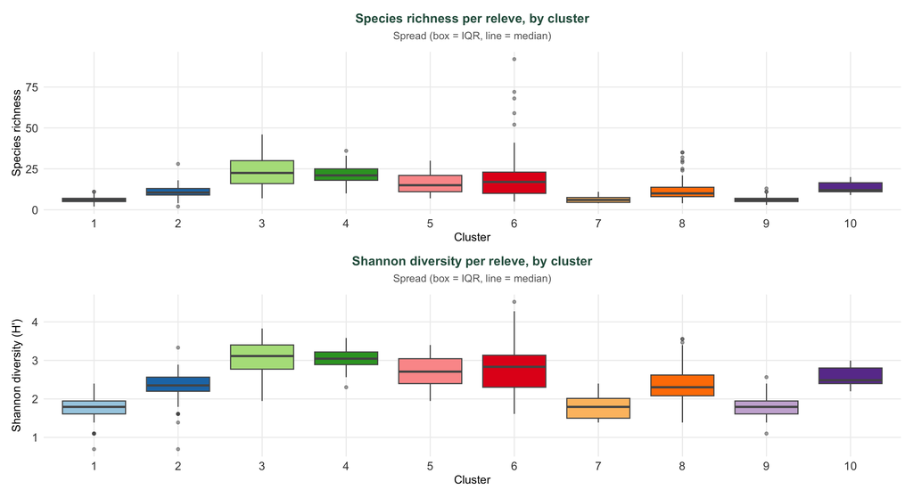

### Per-Cluster Summary Table

|  | Cluster | Releves (n) | Mean richness | SD richness | Mean Shannon | Mean Simpson | Mean evenness | Dominant class | Dominant association |
| --- | --- | --- | --- | --- | --- | --- | --- | --- | --- |
| 1 | 6 | 107 | 19.7 | 14.3 | 2.79 | 0.93 | 1 | MONTIO-CARDAMINETEA | Asplenium trichomanes-Fissidens cristatus |
| 2 | 3 | 68 | 23.5 | 8.7 | 3.08 | 0.95 | 1 | SCHEUCHZERIO-CARICETEA FUSCAE | Eriophorum latifolium-Carex hostiana |
| 3 | 2 | 62 | 10.9 | 4.2 | 2.31 | 0.89 | 1 | MOLINIO-ARRHENATHERETEA | Centaureo-Cynosuretum |
| 4 | 4 | 61 | 21.6 | 5.2 | 3.04 | 0.95 | 1 | OXYCOCCO-SPHAGNETEA | Trichophoreto-Eriophoretum |
| 5 | 8 | 54 | 12.6 | 7.7 | 2.39 | 0.9 | 1 | NARDO-CALLUNETEA | Nardus stricta-Vaccinium myrtillus |
| 6 | 9 | 44 | 6.4 | 2 | 1.82 | 0.83 | 1 | ASTERETEA TRIPOLIUM | Juncus gerardii-Carex extensa |
| 7 | 1 | 38 | 5.8 | 2.2 | 1.69 | 0.8 | 1 | PHRAGMITETEA | Littorella uniflora-Lobelia dortmanna |
| 8 | 5 | 32 | 16.6 | 6.2 | 2.74 | 0.93 | 1 | Unclassified | Epiphytic bryophytes and lichens in the Betula-Vaccinium myrtillus and Corylus-Oxalis acetosella Associations |
| 9 | 7 | 27 | 6.4 | 2.1 | 1.8 | 0.83 | 1 | CARICETEA CURVULAE | Rhacomitreto-Callunettum |
| 10 | 10 | 27 | 13.7 | 3.5 | 2.59 | 0.92 | 1 | QUERCETEA ROBORI-PETRAEAE | Oxalis acetosella-Rhytidiadelphus loreus |

### Narrative Summary — Top 3 Clusters by Size

**Cluster 6** (107 releves, dominated by *MONTIO-CARDAMINETEA* — mostly the *Asplenium trichomanes-Fissidens cristatus* association): mean species richness 19.7 (Shannon H’ = 2.79). Most frequent species: *Deschampsia cespitosa* (36%), *Festuca ovina* (29%), *Ranunculus acris* (25%), *Viola riviniana* (25%), *Thymus drucei* (25%). Statistically significant indicator species: *Deschampsia cespitosa*, *Betula pubescens ssp. odorata*, *Viola riviniana*. **Cluster 3** (68 releves, dominated by *SCHEUCHZERIO-CARICETEA FUSCAE* — mostly the *Eriophorum latifolium-Carex hostiana* association): mean species richness 23.5 (Shannon H’ = 3.08). Most frequent species: *C. nigra* (59%), *C. panicea* (57%), *Campylium stellatum* (56%), *Scorpidium scorpioides* (51%), *Eriophorum angustifolium* (50%). Statistically significant indicator species: *Campylium stellatum*, *Scorpidium scorpioides*, *C. nigra*. **Cluster 2** (62 releves, dominated by *MOLINIO-ARRHENATHERETEA* — mostly the *Centaureo-Cynosuretum* association): mean species richness 10.9 (Shannon H’ = 2.31). Most frequent species: *Plantago lanceolata* (50%), *Agrostis stolonifera* (31%), *Ranunculus repens* (29%), *Festuca rubra* (29%), *Cynosurus cristatus* (26%). Statistically significant indicator species: *Plantago lanceolata*, *Centaurea nigra*, *Trifolium pratense*.

## 9.3 · What Dominates Each Cluster

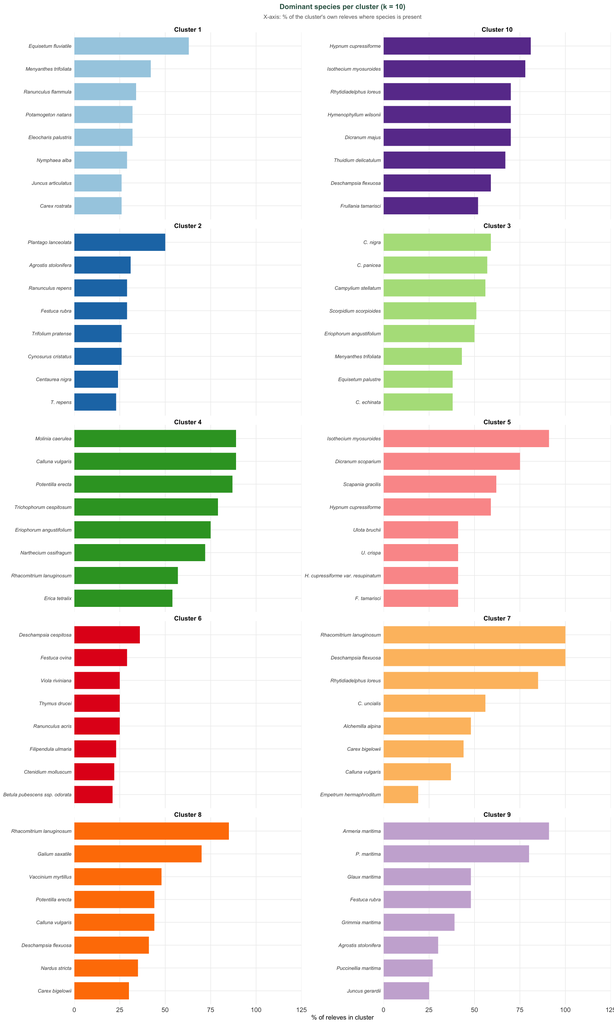

## 9.4 · Cluster Composition — Stacked Proportions

Each bar is one cluster, scaled to 100%. Colour segments show what makes up that cluster’s releves — by dominant species and by parent vegetation class.

[interactive chart not shown]

# 10 · Releve Reference Table

Full geographic index of all 520 releves. Filter, search, or sort any column.

|  | Geo ID | Table | Releve | Ref code | Grid ref | Lat | Lon | Alt (m) | Slope (°) | Aspect (°) | Cover (%) | Spp (n) | Class | Association |
| --- | --- | --- | --- | --- | --- | --- | --- | --- | --- | --- | --- | --- | --- | --- |
| 1 | 1 | table_4_20 | 4 | B68-013 | NG572007 | 57.0333 | -6.0033 | 91 |  | 270 | 100 | 55 | SCHEUCHZERIO-CARICETEA FUSCAE | Molinia caerulea-Myrica gale |
| 2 | 2 | table_4_25 | 3 | B68-012 | NG587007 | 57.0341 | -5.9786 | 61 | 10 | 135 | 100 | 98 | SCHEUCHZERIO-CARICETEA FUSCAE | Eriophorum latifolium-Carex hostiana |
| 3 | 3 | table_4_13 | 12 | B68-014 | NG572012 | 57.0378 | -6.0037 | 61 |  |  | 50 | 17 | PHRAGMITETEA | Schoenoplectus lacustris-Phragmites communis (Schoenoplectus-Equisetum fluviatile subass.) |
| 4 | 4 | table_4_37 | 1 | B68-328 | NG576012 | 57.038 | -5.9972 | 152 | 5 | 225 | 100 |  | CARICETEA CURVULAE | Rhacomitreto-Callunettum |
| 5 | 5 | table_4_13 | 5 | B68-015 | NG574018 | 57.0432 | -6.001 | 61 |  |  | 75 | 20 | PHRAGMITETEA | Schoenoplectus lacustris-Phragmites communis (Phragmites-Equisetum fluviatile subass.) |
| 6 | 6 | table_4_13 | 6 | B68-017 | NG574018 | 57.0432 | -6.001 | 61 |  |  | 90 | 20 | PHRAGMITETEA | Schoenoplectus lacustris-Phragmites communis (Phragmites-Equisetum fluviatile subass.) |
| 7 | 7 | table_4_18 | 5 | B68-016 | NG574018 | 57.0432 | -6.001 | 61 |  |  | 75 | 38 | SCHEUCHZERIO-CARICETEA FUSCAE | Carex lasiocarpa-Menyanthes trifoliata |
| 8 | 8 | table_4_47 | 5 | B67-104 | NG603077 | 57.0976 | -5.959 | 61 | 20 | 45 | 100 | 194 | BETULO-ADENOSTYLETEA | Betula pubescens-Cirsium heterophyllum / Sedum rosea-Alchemilla glabra |
| 9 | 9 | table_4_45 | 1 | B67-106 | NG603078 | 57.0985 | -5.9591 | 76 | 5 | 0 | 100 | 75 | BETULO-ADENOSTYLETEA | Luzula sylvatica-Vaccinium myrtillus |
| 10 | 10 | table_4_49 | 9 | B67-105 | NG603081 | 57.1012 | -5.9594 | 30 | 35 | 0 | 100 |  | QUERCETEA ROBORI-PETRAEAE | Betula pubescens-Vaccinium myrtillus / Corylus avellana-Oxalis acetosella |

[output cut: 510 more lines]

*Analysis by Bhagyesh and Pawan · Data: Birks H.J.B. (1973)*